# Business_Forecasting

```r
auto.arima(NITS, stepwise=TRUE, trace=FALSE, approximation=FALSE)
```

```
## Series: NITS
## ARIMA(2,1,1)
##
## Coefficients:
##          ar1      ar2     ma1
##       0.5013  -0.3525  0.6409
## s.e.  0.1958   0.1824  0.1657
##
## sigma^2 estimated as 5322:  log likelihood=-221.93
## AIC=451.87   AICc=453.04   BIC=458.52
```

. Based on the ACF and PACF, which are the possible ARIMA model possible?

```r
fit_Arima <- Arima(NITS, order=c(2,1,1))
```

. Show the AIC, BIC and Sigma^2 for the possible models?

```r
summary(fit_Arima)
```

```
## Series: NITS
## ARIMA(2,1,1)
##
## Coefficients:
##          ar1      ar2     ma1
##       0.5013  -0.3525  0.6409
## s.e.  0.1958   0.1824  0.1657
##
## sigma^2 estimated as 5322:  log likelihood=-221.93
## AIC=451.87   AICc=453.04   BIC=458.52
##
## Training set error measures:
##                    ME     RMSE      MAE      MPE     MAPE      MASE
## Training set 7.607852 69.20748 42.97381 0.263098 1.657254 0.2074498
##                     ACF1
## Training set -0.03197029
```

. Perform Residual Analysis for this technique. o Do a plot of residuals. What does the plot indicate?

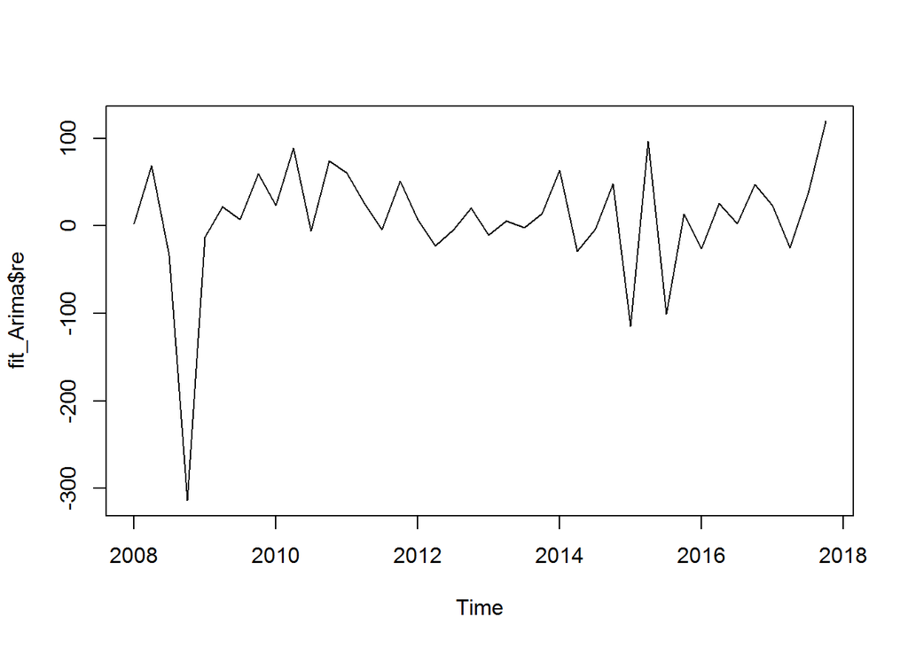

```r
plot(fit_Arima$re)
```

The residual plot using ARIMA is almost similar to our time series model.The residual plot captures the steep rise and fall in the beginning

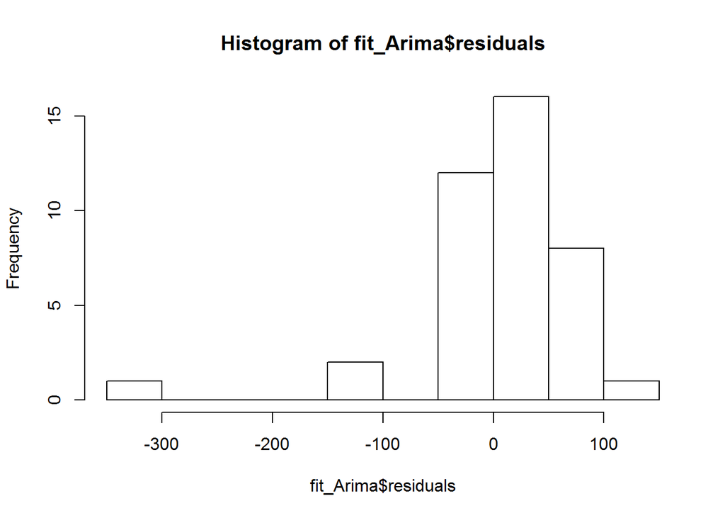

```r
hist(fit_Arima$residuals)
```

Histogram of the residuals looks severely left skewed. It also doesn’t have any specific pattern or not even close to a normal distribution

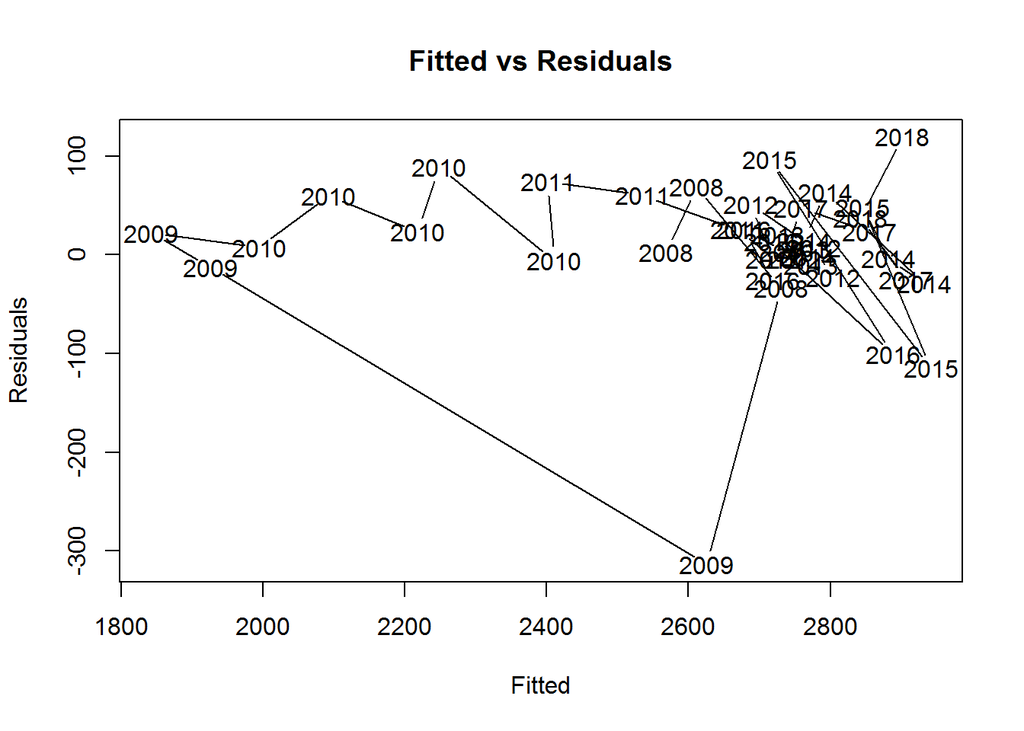

```r
plot(fit_Arima$fitted,fit_Arima$residuals,xlab='Fitted',ylab='Residuals',main='Fitted vs Residuals')
```

Fitted vs residual plots doesn’t seem to have any specific pattern and outliers are also present

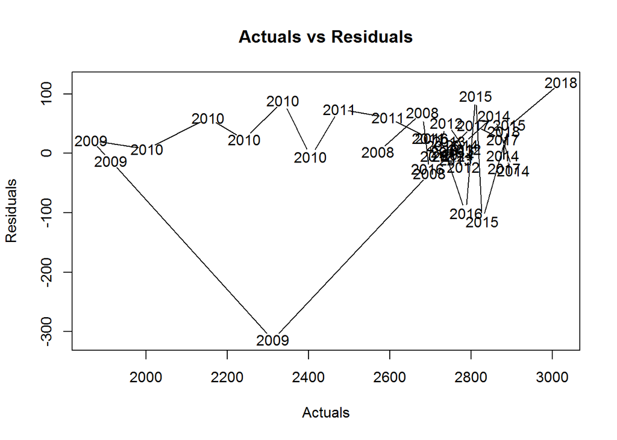

```r
plot(NITS,fit_Arima$residuals,xlab='Actuals',ylab='Residuals',main='Actuals vs Residuals')
```

Actual vs residual plots doesn’t seem to have any specific pattern and outliers are also present

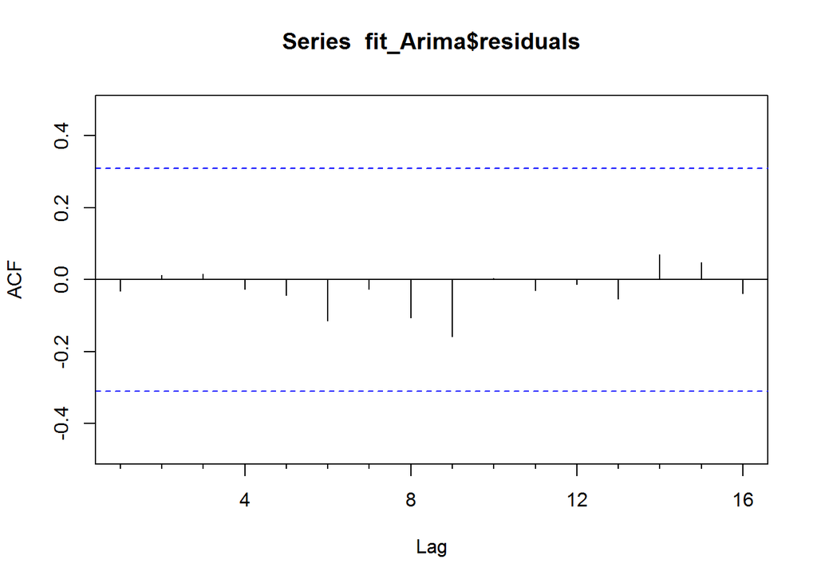

```r
Acf(fit_Arima$residuals)
```

There is no significant lines which are present. Also most of the points are close to zero.

```r
accuracy(fit_Arima)
```

```
##                    ME     RMSE      MAE      MPE     MAPE      MASE
## Training set 7.607852 69.20748 42.97381 0.263098 1.657254 0.2074498
##                     ACF1
## Training set -0.03197029
```

. Forecast o Next one year. Show table and plot

```r
fo<-forecast(fit_Arima,h=4)
fo
```

```
##         Point Forecast    Lo 80    Hi 80    Lo 95    Hi 95
## 2018 Q1       3169.929 3076.438 3263.419 3026.947 3312.910
## 2018 Q2       3194.406 2973.382 3415.430 2856.379 3532.433
## 2018 Q3       3154.390 2841.935 3466.844 2676.532 3632.247
## 2018 Q4       3125.701 2758.169 3493.233 2563.609 3687.793
```

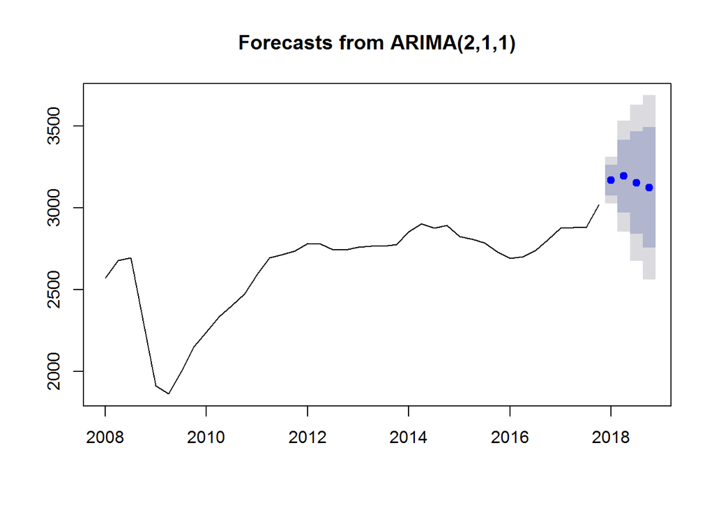

```r
plot(fo)
```

. Forecast o Next two year. Show table and plot

```r
fo<-forecast(fit_Arima,h=8)
fo
```

```
##         Point Forecast    Lo 80    Hi 80    Lo 95    Hi 95
## 2018 Q1       3169.929 3076.438 3263.419 3026.947 3312.910
## 2018 Q2       3194.406 2973.382 3415.430 2856.379 3532.433
## 2018 Q3       3154.390 2841.935 3466.844 2676.532 3632.247
## 2018 Q4       3125.701 2758.169 3493.233 2563.609 3687.793
## 2019 Q1       3125.426 2719.395 3531.456 2504.455 3746.396
## 2019 Q2       3135.400 2694.557 3576.243 2461.189 3809.612
## 2019 Q3       3140.498 2664.831 3616.165 2413.028 3867.968
## 2019 Q4       3139.537 2630.082 3648.992 2360.393 3918.681
```

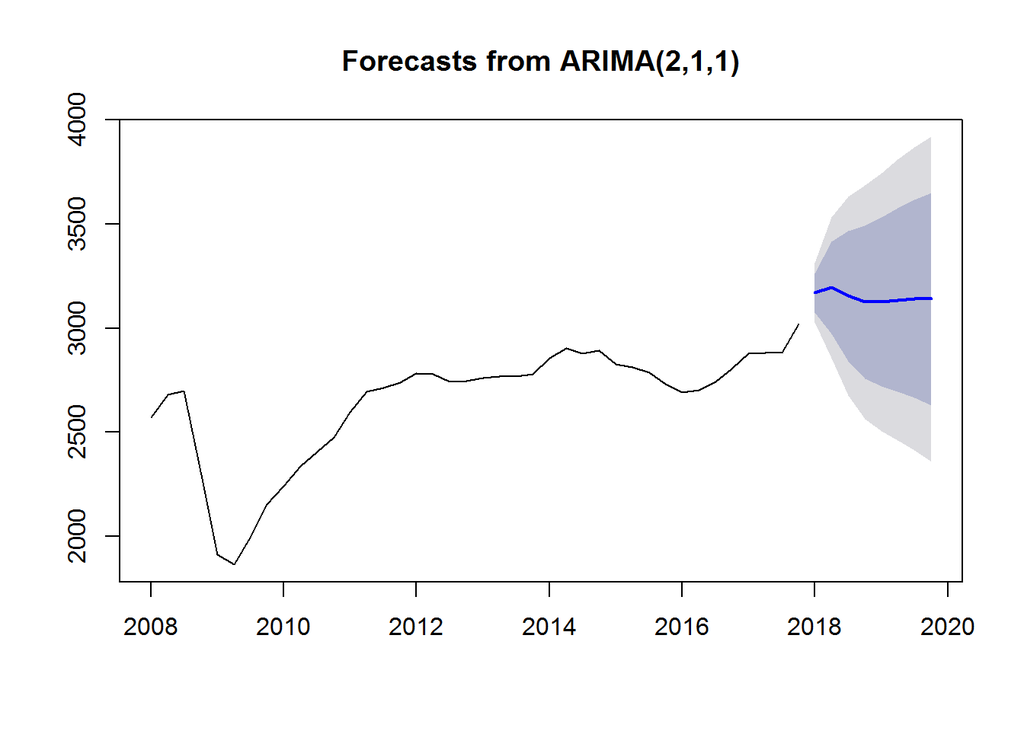

```r
plot(fo)
```

Model Comparision Model Accuracy Metrics  
ME RMSE MAE MPE MAPE MASE ACF1 Naïve Method 11.54359 109.7054 68.08205 0.2970542 2.852688 0.3286562 0.5405785 Simple Smoothing 12.9118 108.8364 68.04088 0.3540331 2.845989 0.3284575 0.5489618 Holt Winters 41.5499 210.1229 145.5452 1.67805 5.850816 0.7025981 0.3363672 ARIMA 7.607852 69.20748 42.97381 0.263098 1.657254 0.2074498 -0.03197029